# PML Project write up submission

Kelvin wan

Sunday, March 22, 2015

# Background

Using devices such as Jawbone Up, Nike FuelBand, and Fitbit it is now possible to collect a large amount of data about personal activity relatively inexpensively. These type of devices are part of the quantified self movement - a group of enthusiasts who take measurements about themselves regularly to improve their health, to find patterns in their behavior, or because they are tech geeks. One thing that people regularly do is quantify how much of a particular activity they do, but they rarely quantify how well they do it.

In this project, we will use data from accelerometers on the belt, forearm, arm, and dumbell of 6 participants. They were asked to perform barbell lifts correctly and incorrectly in 5 different ways. More information is available from the website here: http://groupware.les.inf.puc-rio.br/har (see the section on the Weight Lifting Exercise Dataset).

# Aim

The goal of this project is to predict the manner in which they did the exercise. This is the “classe” variable in the training set.

# Data Preparation

The training data for this project are available here:

https://d396qusza40orc.cloudfront.net/predmachlearn/pml-training.csv

The test data are available here:

https://d396qusza40orc.cloudfront.net/predmachlearn/pml-testing.csv

The data for this project come from this source: http://groupware.les.inf.puc-rio.br/har.

Our data preparation work includes: 1. Loading the required libraries 2. Reading the training and testing datasets 3. Cleaning data with ‘NA’ or blank entries

```r
#install.packages("caret")
#install.packages("randomForest")
#install.packages("rpart")
#install.packages("rpart.plot")

library(caret)
library(randomForest)
library(rpart)
library(rpart.plot)
```

```r
#download.file("https://d396qusza40orc.cloudfront.net/predmachlearn/pml-training.csv", destfile = "./PML - Submission/pml-training.csv")
#download.file("https://d396qusza40orc.cloudfront.net/predmachlearn/pml-testing.csv", destfile = "./PML - Submission/pml-testing.csv")
#

trainingdata <- read.csv("pml-training.csv", header = TRUE, na.strings = c("NA", ""))
testingdata <- read.csv("pml-testing.csv", header = TRUE, na.strings = c("NA", ""))
dim(trainingdata)
```

```
## [1] 19622   160
```

```r
dim(testingdata)
```

```
## [1]  20 160
```

```r
#Delete variables with all missing values
trainingdena <- trainingdata[ , colSums(is.na(trainingdata)) == 0]
testingdena <- testingdata[ , colSums(is.na(testingdata)) == 0]

#Remove variables not relevant for this project
trainingcleaned <- trainingdena[,-c(1:7)]
testingcleaned <- testingdena[,-c(1:7)]

dim(trainingcleaned)
```

```
## [1] 19622    53
```

```r
dim(testingcleaned)
```

```
## [1] 20 53
```

# Seperating the Data

Split the cleaned training dataset into 2: 70% for training the model and 30% for validation.

```r
intrain <- createDataPartition(trainingcleaned$classe, p=0.7, list=FALSE)
training <- trainingcleaned[intrain,]
validation <- trainingcleaned[-intrain,]
dim(training)
```

```
## [1] 13737    53
```

```r
dim(validation)
```

```
## [1] 5885   53
```

# Modeling

## Decision Tree

Decision tree approach used in training the model.

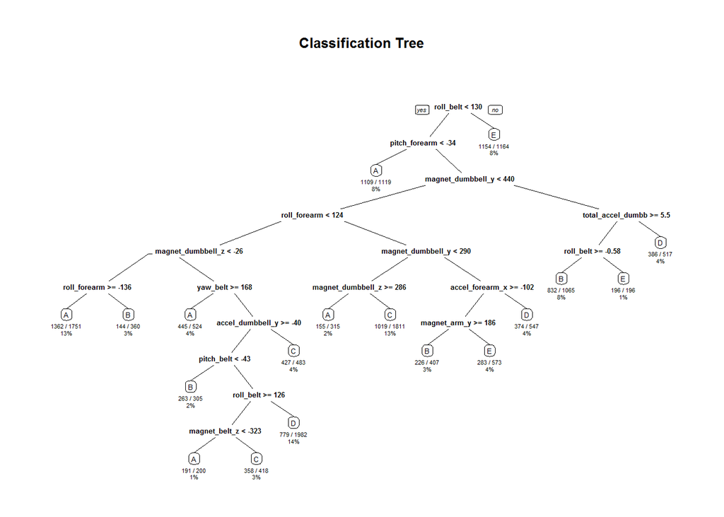

```r
trainingdt <- rpart(classe ~ ., data=training, method="class")
rpart.plot(trainingdt, main="Classification Tree", extra=102, under=TRUE, faclen=0)
```

## Random Forests

Explored using the random forest approach in training the model.

```r
require(randomForest)
set.seed(123)

trainingrf <- randomForest(classe~.,data=training,ntree=100, importance=TRUE)
trainingrf
```

```
##
## Call:
##  randomForest(formula = classe ~ ., data = training, ntree = 100,      importance = TRUE)
##                Type of random forest: classification
##                      Number of trees: 100
## No. of variables tried at each split: 7
##
##         OOB estimate of  error rate: 0.65%
## Confusion matrix:
##      A    B    C    D    E class.error
## A 3902    2    1    0    1 0.001024066
## B   17 2631   10    0    0 0.010158014
## C    0   22 2369    5    0 0.011268781
## D    0    0   23 2228    1 0.010657194
## E    0    0    3    4 2518 0.002772277
```

```r
trainingrf2 <- predict(trainingrf, newdata=validation)
```

# Results

Applied the random forest model to the initial testing dataset and display the predicted results.

```r
answers <- predict(trainingrf, testingdata)
answers
```

```
##  1  2  3  4  5  6  7  8  9 10 11 12 13 14 15 16 17 18 19 20
##  B  A  B  A  A  E  D  B  A  A  B  C  B  A  E  E  A  B  B  B
## Levels: A B C D E
```